# R Notebook

**Principles of Data Visualization and Introduction to ggplot2**

```r
library(ggplot2)
```

I have provided you with data about the 5,000 fastest growing companies in the US, as compiled by Inc. magazine. lets read this in:

```r
inc <- read.csv("https://raw.githubusercontent.com/charleyferrari/CUNY_DATA_608/master/module1/Data/inc5000_data.csv", header= TRUE)
```

And lets preview this data:

```r
head(inc)
```

```
  Rank                         Name Growth_Rate   Revenue                     Industry
1    1                         Fuhu      421.48 1.179e+08 Consumer Products & Services
2    2        FederalConference.com      248.31 4.960e+07          Government Services
3    3                The HCI Group      245.45 2.550e+07                       Health
4    4                      Bridger      233.08 1.900e+09                       Energy
5    5                       DataXu      213.37 8.700e+07      Advertising & Marketing
6    6 MileStone Community Builders      179.38 4.570e+07                  Real Estate
  Employees         City State
1       104   El Segundo    CA
2        51     Dumfries    VA
3       132 Jacksonville    FL
4        50      Addison    TX
5       220       Boston    MA
6        63       Austin    TX
```

```r
summary(inc)
```

```
      Rank                          Name       Growth_Rate         Revenue
 Min.   :   1   (Add)ventures         :   1   Min.   :  0.340   Min.   :2.000e+06
 1st Qu.:1252   @Properties           :   1   1st Qu.:  0.770   1st Qu.:5.100e+06
 Median :2502   1-Stop Translation USA:   1   Median :  1.420   Median :1.090e+07
 Mean   :2502   110 Consulting        :   1   Mean   :  4.612   Mean   :4.822e+07
 3rd Qu.:3751   11thStreetCoffee.com  :   1   3rd Qu.:  3.290   3rd Qu.:2.860e+07
 Max.   :5000   123 Exteriors         :   1   Max.   :421.480   Max.   :1.010e+10
                (Other)               :4995
                         Industry      Employees                  City          State
 IT Services                 : 733   Min.   :    1.0   New York     : 160   CA     : 701
 Business Products & Services: 482   1st Qu.:   25.0   Chicago      :  90   TX     : 387
 Advertising & Marketing     : 471   Median :   53.0   Austin       :  88   NY     : 311
 Health                      : 355   Mean   :  232.7   Houston      :  76   VA     : 283
 Software                    : 342   3rd Qu.:  132.0   San Francisco:  75   FL     : 282
 Financial Services          : 260   Max.   :66803.0   Atlanta      :  74   IL     : 273
 (Other)                     :2358   NA's   :12        (Other)      :4438   (Other):2764
```

Think a bit on what these summaries mean. Use the space below to add some more relevant non-visual exploratory information you think helps you understand this data:

```r
# Insert your code here, create more chunks as necessary
less_100_emp = subset(inc, Employees < 100)
btwn_100_1000_emp = subset(inc,  (Employees <= 1000) & (Employees >= 100))
grtr_1000_emp = subset(inc,  Employees > 1000)
na_emp = subset(inc, is.na(inc$Employees) )
summary(less_100_emp)
```

```
      Rank                                     Name       Growth_Rate         Revenue
 Min.   :   2   (Add)ventures                    :   1   Min.   :  0.340   Min.   :2.00e+06
 1st Qu.:1134   @Properties                      :   1   1st Qu.:  0.810   1st Qu.:4.10e+06
 Median :2384   1-Stop Translation USA           :   1   Median :  1.515   Median :7.20e+06
 Mean   :2415   11thStreetCoffee.com             :   1   Mean   :  4.707   Mean   :1.43e+07
 3rd Qu.:3674   1st American Systems and Services:   1   3rd Qu.:  3.700   3rd Qu.:1.38e+07
 Max.   :5000   1st Equity                       :   1   Max.   :248.310   Max.   :1.90e+09
                (Other)                          :3418
                         Industry      Employees                City          State
 IT Services                 : 493   Min.   : 1.00   New York     : 112   CA     : 507
 Advertising & Marketing     : 396   1st Qu.:19.00   Austin       :  64   TX     : 240
 Business Products & Services: 334   Median :32.00   Chicago      :  63   NY     : 227
 Software                    : 216   Mean   :39.14   San Francisco:  54   FL     : 195
 Health                      : 210   3rd Qu.:55.00   Atlanta      :  53   VA     : 187
 Manufacturing               : 175   Max.   :99.00   San Diego    :  53   IL     : 182
 (Other)                     :1600                   (Other)      :3025   (Other):1886
```

```r
summary(btwn_100_1000_emp)
```

```
      Rank                             Name       Growth_Rate         Revenue
 Min.   :   1   110 Consulting           :   1   Min.   :  0.350   Min.   :2.10e+06
 1st Qu.:1491   123 Exteriors            :   1   1st Qu.:  0.730   1st Qu.:1.72e+07
 Median :2704   2020 Exhibits            :   1   Median :  1.300   Median :3.14e+07
 Mean   :2646   21c Museum Hotels        :   1   Mean   :  4.523   Mean   :6.99e+07
 3rd Qu.:3855   22nd Century Technologies:   1   3rd Qu.:  2.680   3rd Qu.:6.62e+07
 Max.   :4990   29 Prime                 :   1   Max.   :421.480   Max.   :2.70e+09
                (Other)                  :1391
                         Industry     Employees                 City          State
 IT Services                 :227   Min.   : 100.0   New York     :  42   CA     :176
 Business Products & Services:131   1st Qu.: 138.0   Houston      :  30   TX     :129
 Health                      :128   Median : 202.0   Austin       :  24   VA     : 92
 Software                    :118   Mean   : 275.8   Chicago      :  20   FL     : 76
 Financial Services          : 87   3rd Qu.: 345.0   San Francisco:  20   NY     : 75
 Manufacturing               : 74   Max.   :1000.0   Atlanta      :  18   IL     : 71
 (Other)                     :632                    (Other)      :1243   (Other):778
```

```r
summary(grtr_1000_emp)
```

```
      Rank                      Name      Growth_Rate         Revenue
 Min.   :  15   ABC Supply        :  1   Min.   :  0.340   Min.   :2.900e+06
 1st Qu.:2090   Acadian Companies :  1   1st Qu.:  0.630   1st Qu.:8.358e+07
 Median :3404   Accurate Home Care:  1   Median :  0.915   Median :2.265e+08
 Mean   :3050   Acro Service      :  1   Mean   :  3.488   Mean   :5.603e+08
 3rd Qu.:4128   Addison Group     :  1   3rd Qu.:  1.785   3rd Qu.:5.091e+08
 Max.   :4997   Advanced Disposal :  1   Max.   :123.330   Max.   :1.010e+10
                (Other)           :162
                         Industry    Employees             City         State
 Human Resources             :21   Min.   : 1001   Chicago   :  7   IL     :19
 Health                      :16   1st Qu.: 1325   New York  :  6   CA     :17
 Business Products & Services:15   Median : 1948   Dallas    :  5   TX     :17
 Food & Beverage             :15   Mean   : 3820   Houston   :  5   FL     :11
 Financial Services          :12   3rd Qu.: 3899   Charlotte :  4   NY     : 9
 IT Services                 :12   Max.   :66803   Cincinnati:  3   MI     : 7
 (Other)                     :77                   (Other)   :138   (Other):88
```

```r
summary(na_emp)
```

```
      Rank                                    Name    Growth_Rate        Revenue
 Min.   : 183   Carolinas Home Medical Equipment:1   Min.   : 0.350   Min.   :  2700000
 1st Qu.:1521   Excalibur Exhibits              :1   1st Qu.: 0.670   1st Qu.:  5025000
 Median :2470   First Flight Solutions          :1   Median : 1.475   Median :  9400000
 Mean   :2606   Global Communications Group     :1   Mean   : 3.408   Mean   : 35408333
 3rd Qu.:4012   Heartland Business Systems      :1   3rd Qu.: 2.700   3rd Qu.: 52275000
 Max.   :4968   Higher Logic                    :1   Max.   :22.320   Max.   :156300000
                (Other)                         :6
                         Industry   Employees             City       State
 Business Products & Services:2   Min.   : NA   Atlanta     :1   NC     :2
 Food & Beverage             :2   1st Qu.: NA   Bellevue    :1   WI     :2
 Telecommunications          :2   Median : NA   Emerald Isle:1   CA     :1
 Health                      :1   Mean   :NaN   Englewood   :1   CO     :1
 IT Services                 :1   3rd Qu.: NA   Horsham     :1   DC     :1
 Logistics & Transportation  :1   Max.   : NA   houston     :1   GA     :1
 (Other)                     :3   NA's   :12    (Other)     :6   (Other):4
```

## Question 1

Create a graph that shows the distribution of companies in the dataset by State (ie how many are in each state). There are a lot of States, so consider which axis you should use. This visualization is ultimately going to be consumed on a ‘portrait’ oriented screen (ie taller than wide), which should further guide your layout choices.

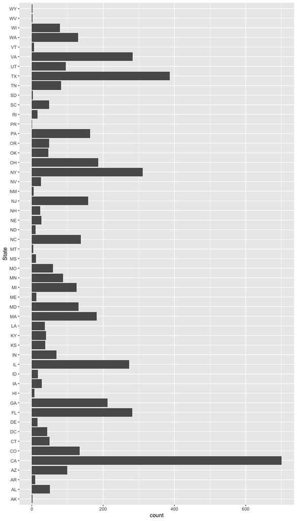

```r
# Answer Question 1 here
ggplot(inc, aes(x=State)) + geom_bar() + coord_flip()
```

## Quesiton 2

Lets dig in on the state with the 3rd most companies in the data set. Imagine you work for the state and are interested in how many people are employed by companies in different industries. Create a plot that shows the average and/or median employment by industry for companies in this state (only use cases with full data, use R’s `complete.cases()` function.) In addition to this, your graph should show how variable the ranges are, and you should deal with outliers.

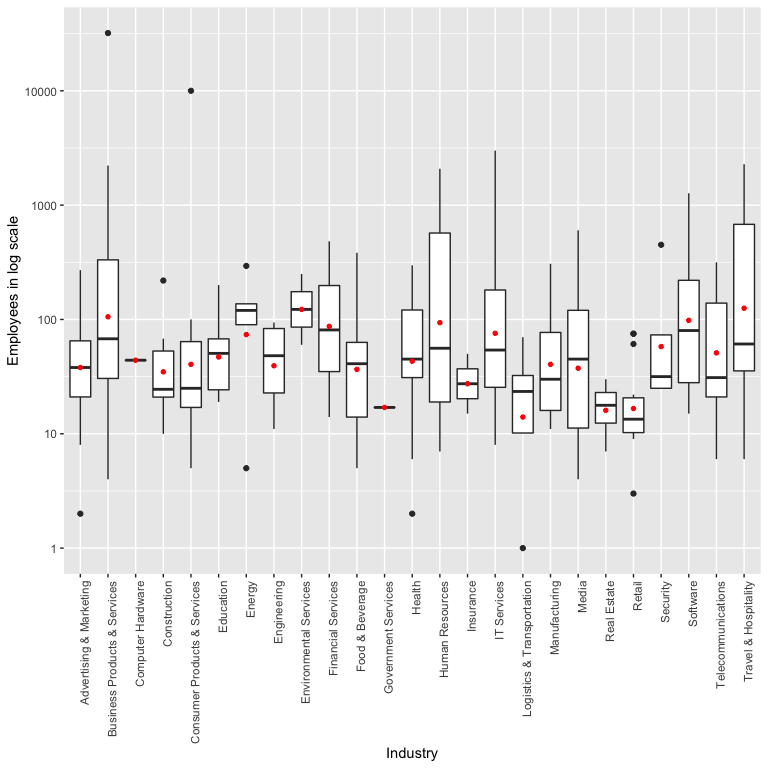

```r
# Answer Question 2 here
counts = count(inc, vars=State, sort = TRUE)
ordered_states = counts %>% pull(vars)
third_most_state = ordered_states[3]
NY_state = subset(inc, State == third_most_state)
subset = NY_state[complete.cases(NY_state),]
ggplot(subset, aes(y = Employees, x = Industry)) + geom_boxplot() + scale_y_continuous(trans='log10') + stat_summary(fun.y=mean, geom="point", shape=20, size=2, color="red", fill="red") + ylab('Employees in log scale') + theme(axis.text.x = element_text(angle = 90, hjust = 1))
```

## Question 3

Now imagine you work for an investor and want to see which industries generate the most revenue per employee. Create a chart that makes this information clear. Once again, the distribution per industry should be shown.

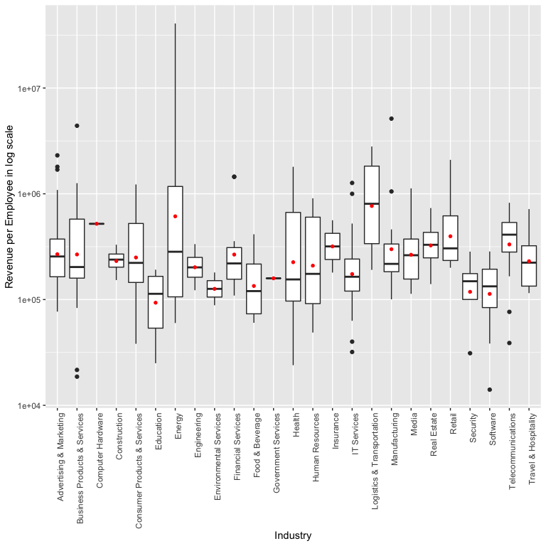

```r
# Answer Question 3 here
# Assuming still for NY state
NY_state$Rev_per_emp = NY_state$Revenue/NY_state$Employees
subset = NY_state[complete.cases(NY_state),]
ggplot(subset, aes(y = Rev_per_emp, x = Industry)) + geom_boxplot() + scale_y_continuous(trans='log10') + stat_summary(fun.y=mean, geom="point", shape=20, size=2, color="red", fill="red") + ylab('Revenue per Employee in log scale') + theme(axis.text.x = element_text(angle = 90, hjust = 1))
```